# 01 - Case Study: Pilgrim Online Banking

Nils Gandlau

15 10 2019

## Data Cleaning

Renaming variables for convenience:

```r
data <- dataOriginal %>%
  rename(profit = "9Profit",
         online = "9Online",
         age = "9age",
         income = "9Inc",
         tenure = "9Tenure",
         district = "9District")

str(data)
```

```
## Classes 'data.table' and 'data.frame':   31634 obs. of  7 variables:
##  $ ID      : num  1 2 3 4 5 6 7 8 9 10 ...
##  $ profit  : num  21 -6 -49 -4 -61 -38 -19 59 493 -158 ...
##  $ online  : num  0 0 1 0 0 0 0 0 0 0 ...
##  $ age     : num  NA 6 5 NA 2 NA 3 5 4 6 ...
##  $ income  : num  NA 3 5 NA 9 3 1 8 9 8 ...
##  $ tenure  : num  6.33 29.5 26.41 2.25 9.91 ...
##  $ district: num  1200 1200 1100 1200 1200 1300 1300 1200 1200 1100 ...
##  - attr(*, ".internal.selfref")=<externalptr>
```

Should we encode `district` as a factor? How many unique values does the feature have?

```r
unique(data$district)
```

```
## [1] 1200 1100 1300
```

Convert some columns to factor variables. This is important for regression models.

```r
data <- data %>%
  mutate(online = as.factor(online),
         age = as.factor(age),
         income = as.factor(income),
         district = as.factor(district)) %>%
  setDT()

str(data)
```

```
## Classes 'data.table' and 'data.frame':   31634 obs. of  7 variables:
##  $ ID      : num  1 2 3 4 5 6 7 8 9 10 ...
##  $ profit  : num  21 -6 -49 -4 -61 -38 -19 59 493 -158 ...
##  $ online  : Factor w/ 2 levels "0","1": 1 1 2 1 1 1 1 1 1 1 ...
##  $ age     : Factor w/ 7 levels "1","2","3","4",..: NA 6 5 NA 2 NA 3 5 4 6 ...
##  $ income  : Factor w/ 9 levels "1","2","3","4",..: NA 3 5 NA 9 3 1 8 9 8 ...
##  $ tenure  : num  6.33 29.5 26.41 2.25 9.91 ...
##  $ district: Factor w/ 3 levels "1100","1200",..: 2 2 1 2 2 3 3 2 2 1 ...
##  - attr(*, ".internal.selfref")=<externalptr>
```

### Missing Values

Count the number of NAs for each variable.

```r
nas <- rbindlist(lapply(names(data), function(colname) {
  nMissingValues <- sum(is.na(data[, get(colname)]))
  return(data.table(feature = colname, number_of_nas = nMissingValues))
}))

nas
```

```
##     feature number_of_nas
## 1:       ID             0
## 2:   profit             0
## 3:   online             0
## 4:      age          8289
## 5:   income          8261
## 6:   tenure             0
## 7: district             0
```

Age and income have roughly the same number of missing values: Is that coincidence, or can we say that when we don’t know the age of a person, we also don’t know her age? To answer this, we count the number of rows for which *both* age and income are NA.

```r
data[, age_and_income_missing := ifelse(is.na(age) & is.na(income), 1, 0)]
cat("n_rows where both age and income are NA:", sum(data$age_and_income_missing))
```

```
## n_rows where both age and income are NA: 7728
```

```r
data[, age_and_income_missing := NULL]
```

So yes, in most rows where either age or income are missing, both age and income are missing. Hence, we know that when we remove all rows that contain a missing value anywhere, we will remove roughly 8000 – which is not too bad considering we have 30k observations in total.

```r
# Remove all rows that contain at least one NA
dataCleaned <- na.omit(data)

# Total rows removed
cat("Rows removed:", nrow(data) - nrow(dataCleaned))
```

```
## Rows removed: 8822
```

## Data Exploration

### Counting

```r
(nOnlinesOfflines <- data.table(
  n_onlines = nrow(data[online == 1]),
  n_offlines = nrow(data[online == 0])
))
```

```
##    n_onlines n_offlines
## 1:      3854      27780
```

### Plotting Features against Target

Plot each predictor against the target variable respectively. This way we get a first impression on their relationships.

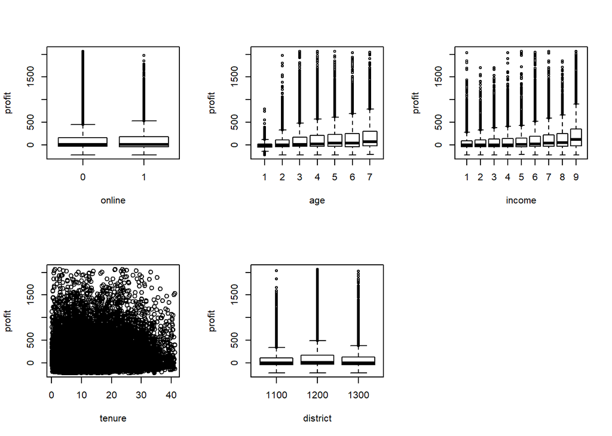

```r
par(mfrow = c(2, 3))
plot(profit~., data %>% select(-ID))
```

- We notice that age and income show a similar pattern, reinforcing the intution that those two predictors are probably correlated: One would think that income increases when you get older.

### Distribution of profits across online/offline customers

- The profits of online & offline customers seem to resemble a pareto-distribution
- The highest-profitable customers are offline (this might be because we simply have a lot more offline customres in the data than online customers)
- The mass of slightly profitable customers seems to be larger for online customers

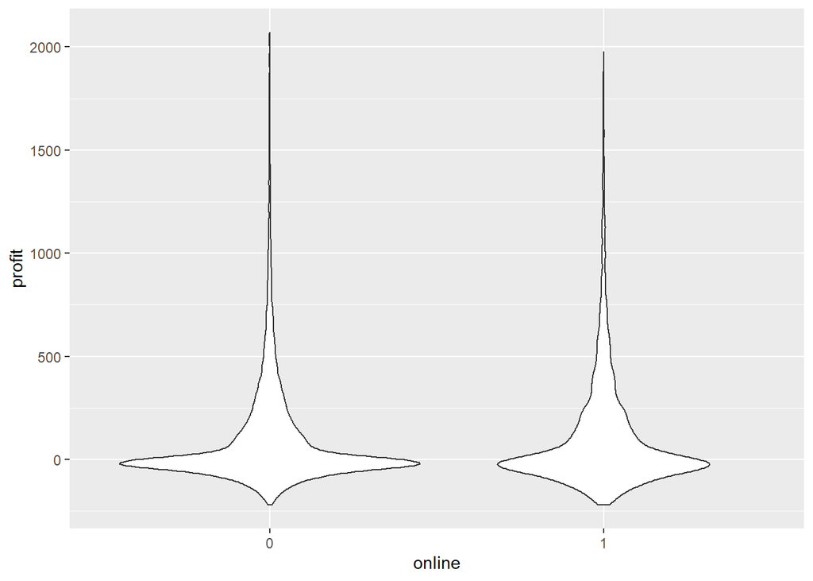

```r
ggplot(data, aes(y = profit, x = online)) +
  geom_violin()
```

### Non-linear relationship between `profit` and `age`

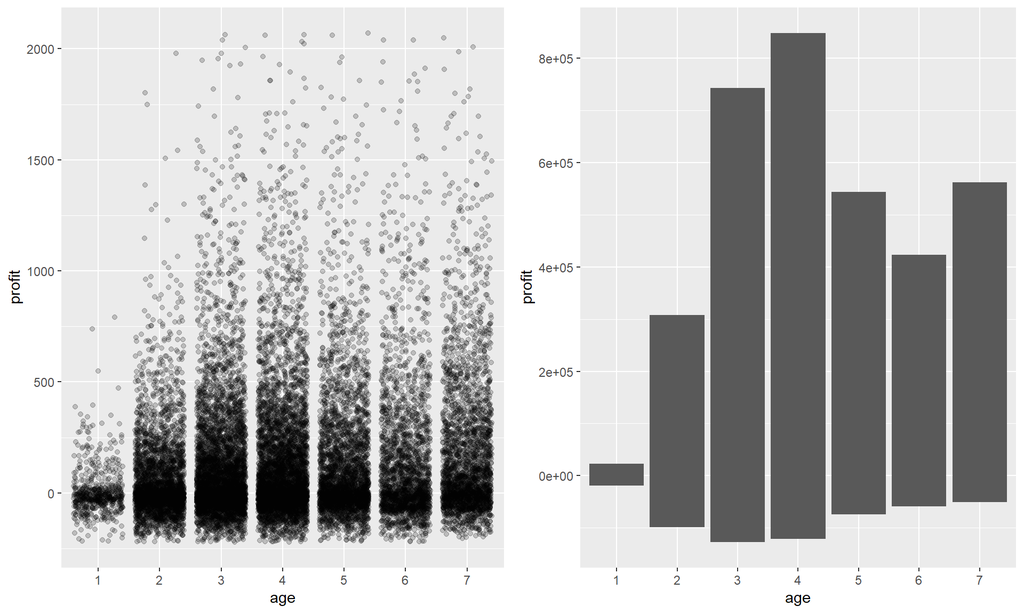

```r
p1 <- ggplot(dataCleaned, aes(x = age, y = profit)) +
  geom_jitter(alpha = 0.2)

p2 <- ggplot(dataCleaned, aes(x = age, y = profit)) +
  geom_histogram(stat = "identity")

cowplot::plot_grid(p1, p2, nrow = 1)
```

- there seems to be a non-linearity in the relationship between `profit` and `age`. If age were a continuous feature,we might have used a polynomial of degree 2 or 3 to estimate their relationship.

### Intuition

- Older people are less likely to use online-banking. However, since they are richer, they may also be more profitable.
- Maybe we have to ask whether the effect of being online changes with age – I would assume that for customers in their 20s, the effect of using online-banking is not too large, since they don’t have money anyway. They might even be negative, since online-banking makes smaller, non-profitable transactions more convenient, thus driving up costs. **Thus we might consider interaction effects `age * online` for the regression model.**

### Correlation Matrix of predictors

We check for correlation across all possible predictors, since we want to avoid the issues of **multicolinearity** (correlated predictors).

```r
predictors <- dataCleaned[, c("online", "age", "income", "tenure", "district")]
predictors <- predictors[, ':='(online = as.numeric(online),
                                age = as.numeric(age),
                                income = as.numeric(income),
                                district = as.numeric(district))]

correlationMatrix <- round(cor(predictors), 2)
correlationMatrix
```

```
##          online   age income tenure district
## online     1.00 -0.17   0.08  -0.08     0.01
## age       -0.17  1.00  -0.07   0.42    -0.03
## income     0.08 -0.07   1.00   0.04     0.03
## tenure    -0.08  0.42   0.04   1.00    -0.01
## district   0.01 -0.03   0.03  -0.01     1.00
```

- Against intution, age seems to be only weakly correlated with income. Moreover, against intuition, it seems to be *negatively* correlated with income. Why is that?
- age is strongly postitively correlated with tenure => we should avoid including both as predictors in our regression model.
- age and being online are negatively correlated. This reinforces the intuition that older people are less likely to use online banking.
- Since `age` and `tenure` are highly correlated, and `online` and `age` are slightly correlated but `online` and `tenure` aren’t, we may decide to put both `online` and `tenure` into our regression model, leaving `age`outside.

## Linear Regression

### v1

- The interaction effect `age * online` should capture the intution that the effect of using online-banking is different for people without money (young people) and for people with money (older people).

```r
linreg1 <- lm(profit ~ online + age + online*age + district, data = dataCleaned)
summary(linreg1)
```

```
##
## Call:
## lm(formula = profit ~ online + age + online * age + district,
##     data = dataCleaned)
##
## Residuals:
##     Min      1Q  Median      3Q     Max
## -416.83 -164.91  -85.30   70.42 1942.98
##
## Coefficients:
##              Estimate Std. Error t value Pr(>|t|)
## (Intercept)   -28.636     13.668  -2.095 0.036176 *
## online1       -16.200     28.081  -0.577 0.564008
## age2           44.695     13.562   3.296 0.000984 ***
## age3          101.541     13.154   7.719 1.22e-14 ***
## age4          123.187     13.130   9.382  < 2e-16 ***
## age5          131.867     13.505   9.765  < 2e-16 ***
## age6          152.821     13.848  11.036  < 2e-16 ***
## age7          186.142     13.639  13.648  < 2e-16 ***
## district1200   47.113      6.345   7.426 1.16e-13 ***
## district1300   16.094      7.885   2.041 0.041263 *
## online1:age2   30.345     30.286   1.002 0.316381
## online1:age3   45.094     30.007   1.503 0.132905
## online1:age4   44.259     30.234   1.464 0.143237
## online1:age5   68.690     32.720   2.099 0.035797 *
## online1:age6   27.653     38.908   0.711 0.477264
## online1:age7    7.480     40.167   0.186 0.852262
## ---
## Signif. codes:  0 '***' 0.001 '**' 0.01 '*' 0.05 '.' 0.1 ' ' 1
##
## Residual standard error: 279 on 22796 degrees of freedom
## Multiple R-squared:  0.02755,    Adjusted R-squared:  0.02691
## F-statistic: 43.06 on 15 and 22796 DF,  p-value: < 2.2e-16
```

- We notice that the coefficients of the youngest age-categories `online1:age2`, `online1:age3` as well as the oldest two age-categories are insignificant, indicating that for both very young and very old customers, online-banking provides (1) less of a benefit and (2) those effects are also insignificant. This reinforces our intuition that we stated in the former bullet point.
- For middle-aged customers, especially age-category 5, the effect of using online banking is (1) positive, where using online banking increases average profits of a customer in age-category 5 by `68.690 - 16.200 = 52.49` USD compared to when she doesn’t use online banking, and (2) this positive effect is significant, with a p-value of `0.036`.
  - This again reinforces our intuition that there is a combination of (a) having money and (b) using online banking that is very beneficial for the bank.

#### Problems

- We have seen that there is significant negative correlation between features `age` and `online` ($\rho = -0.17$). Thus, our regression coefficients might be biased due to multicolinearity.
- We note that `tenure` is highly correlated with `age` ($\rho = 0.42$). Further, `tenure` is less correlated with `online` ($\rho=-0.08$) than age is. Thus, we may repeat the same linear regression but replace `age` with `tenure`.

### v2: Replacing age with tenure due to correlated features

```r
linreg2 <- lm(profit ~ online + tenure + online*tenure + district, data = dataCleaned)
summary(linreg2)
```

```
##
## Call:
## lm(formula = profit ~ online + tenure + online * tenure + district,
##     data = dataCleaned)
##
## Residuals:
##     Min      1Q  Median      3Q     Max
## -480.29 -154.51  -85.53   66.34 1983.33
##
## Coefficients:
##                Estimate Std. Error t value Pr(>|t|)
## (Intercept)     31.1143     6.5125   4.778 1.78e-06 ***
## online1          1.0199     9.0861   0.112   0.9106
## tenure           5.5812     0.2270  24.588  < 2e-16 ***
## district1200    40.5778     6.3146   6.426 1.34e-10 ***
## district1300    11.1168     7.8598   1.414   0.1573
## online1:tenure   1.3913     0.7691   1.809   0.0705 .
## ---
## Signif. codes:  0 '***' 0.001 '**' 0.01 '*' 0.05 '.' 0.1 ' ' 1
##
## Residual standard error: 278.3 on 22806 degrees of freedom
## Multiple R-squared:  0.03203,    Adjusted R-squared:  0.03182
## F-statistic: 150.9 on 5 and 22806 DF,  p-value: < 2.2e-16
```

#### Problems with using tenure over age

We can also do a rough sanity check on the hypothesis that *online-banking is less beneficial for youngest and oldest customers than it is for middle-aged customers*. Below, we compute for each age category the relative amount of online (offline) customers that have yielded above-average profits (compared to their age-category’s specific average).

```r
# Convert profits to a binary feature that indicates whether a customer
# yielded an above-average profit
dataCleaned[, meanProfit := mean(profit), by = age]
dataCleaned[, isAboveMeanProfit := profit >= meanProfit]

results <- rbindlist(lapply(unique(dataCleaned$age), function(ageCategory) {
  dataTemp <- dataCleaned[age == ageCategory]

  nOnline <- nrow(dataTemp[online == 1])
  nOnlineAboveMeanProfits <- nrow(dataTemp[isAboveMeanProfit == 1 & online == 1])

  nOffline <- nrow(dataTemp[online == 0])
  nOfflineAboveMeanProfits <- nrow(dataTemp[isAboveMeanProfit == 1 & online == 0])

  return(data.table(
    ageCategory = ageCategory,
    percOnlineAboveMeanProfits = round(nOnlineAboveMeanProfits / nOnline, 2),
    percOfflineAboveMeanProfits = round(nOfflineAboveMeanProfits / nOffline, 2)
  ))
}))

results[order(ageCategory)]
```

```
##    ageCategory percOnlineAboveMeanProfits percOfflineAboveMeanProfits
## 1:           1                       0.35                        0.33
## 2:           2                       0.36                        0.31
## 3:           3                       0.37                        0.32
## 4:           4                       0.39                        0.32
## 5:           5                       0.39                        0.33
## 6:           6                       0.35                        0.33
## 7:           7                       0.40                        0.35
```

- Across all age-groups, there seems to be a positive effect of using online-banking
- even the oldest customers seem to benefit from using online-banking (unintuitively they seem to do so by a lot! This is against the findings of our first regression `linreg1`, where we had a very low positive coefficient for the oldest age-category (though the standard error was *very* large and the coefficient was highly insignificant))
- Overall, the table further reinforces the finding that online-banking is beneficial